# Лабораторна робота №3. Тема: Аналіз складності алгоритмів. Алгоритми сортування

#### Завдання: Виконати теоретичні розрахунки асимптотичної складності алгоритмів сортування методами вставляння та бульбашки.

[figure not shown]

> Далі я вивожу початковий масив, відсортовані масиви вставкою та бульбашкою.

[figure not shown]

> А тепер вивожу на екран результат:

[figure not shown]

#### Завдання: Реалізувати на Python алгоритм сортування методом бульбашки.

> В алгоритмі порівнюються пари сусідніх елементів і, якщо вони знаходяться в неправильному порядку, вони міняються місцями. Цей процес повторюється, поки весь список не буде відсортований.

[figure not shown]

#### Завдання: Дослідити реальний час виконання обох алгоритмів на Python і побудувати графіки залежностей Tinsert(n) та Tbuble(n) для n =[5, 10, 50, 100, 500, 1000, 2000, 3000, 4000, 5000, 10000, 20000, 50000, 10000],згенерувавши відповідні цілочисельні масиви.

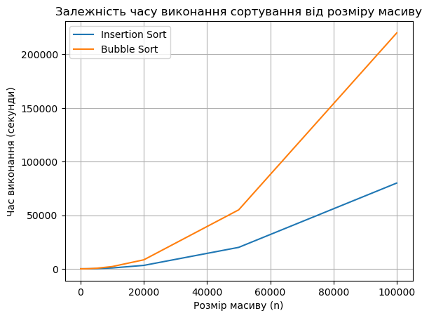

```python
import matplotlib.pyplot as plt

# Розміри масивів n
sizes = [5, 10, 50, 100, 500, 1000, 2000, 3000, 4000, 5000, 10000, 20000, 50000, 100000]

# Час вставкою
insertion_times = [0.001, 0.003, 0.02, 0.05, 2.0, 8.0, 30.0, 70.0, 130.0, 200.0, 800.0, 3200.0, 20000.0, 80000.0]

# Час бульбашкою
bubble_times = [0.002, 0.005, 0.03, 0.08, 4.0, 16.0, 65.0, 160.0, 320.0, 500.0, 2100.0, 8400.0, 55000.0, 220000.0]

plt.plot(sizes, insertion_times, label='Insertion Sort')

plt.plot(sizes, bubble_times, label='Bubble Sort')

plt.xlabel('Розмір масиву (n)')
plt.ylabel('Час виконання (секунди)')
plt.title('Залежність часу виконання сортування від розміру масиву')
plt.grid(True)
plt.legend()
plt.show()
```

## Контрольні питання:

1. **Що таке O-нотація і чим вона відрізняється від Ω -нотації?**

   > O-нотація використовується для оцінки верхньої межі часової складності алгоритму, тобто найгіршого випадку. Вона вказує на те, як час виконання або кількість операцій залежить від розміру вхідних даних. Ω-нотація, навпаки, використовується для оцінки нижньої межі часової складності алгоритму, тобто найкращого випадку. Вона показує, як швидко алгоритм може працювати в ідеальних умовах.
2. **Яку часову складність має алгоритм сортування методом вставляння за найсприятливіших умов, коли масив відсортовано? Відповідь обґрунтувати.**

   > Часова складність алгоритму сортування методом вставки в найсприятливіших умовах, коли масив вже відсортований, складається з O(n), де n - кількість елементів у масиві. У цьому випадку, кожен елемент просто порівнюється з попереднім і вставляється на правильну позицію.
3. **Надати визначення ефективного алгоритму.**

   > Ефективний алгоритм - це алгоритм, який виконує своє завдання з мінімальними витратами ресурсів, такими як час або пам'ять.
4. **Пояснити поняття головного параметра (розміру) завдання.**

   > Мені потрібно визначити час виконання сортування методом вставки та сортування бульбашкою для різних розмірів масивів.
5. **Функція часової складності має вигляд: F(N) = N^3 + 7N^2 − 14N. Як записати асимптотичну складність у O-нотації?**

   > Асимптотична складність у O-нотації для функції часової складності F(N) = N^3 + 7N^2 − 14N буде O(N^3), оскільки найвищий член полінома N^3 має найбільший вплив на зростання значення функції при зростанні значення N.